# Exploratory analysis for Fordgobikeand dataset

```python
#import nessery libiraies
import numpy as np
import pandas as pd
import matplotlib.pyplot as plt
import seaborn as sb
from scipy import stats
#To suppress warningsin visualizations
import warnings
warnings.filterwarnings('ignore')

%matplotlib inline
```

```python
#Read csv file in panda data frame
trips = pd.read_csv('201902-fordgobike-tripdata.csv')
```

```python
#get the number of rows and columns
print(trips.shape)
```

```
(183412, 16)
```

```python
#get the data types of all columns
print(trips.dtypes)
```

```
duration_sec                 int64
start_time                  object
end_time                    object
start_station_id           float64
start_station_name          object
start_station_latitude     float64
start_station_longitude    float64
end_station_id             float64
end_station_name            object
end_station_latitude       float64
end_station_longitude      float64
bike_id                      int64
user_type                   object
member_birth_year          float64
member_gender               object
bike_share_for_all_trip     object
dtype: object
```

```python
trips.head(10)
```

|  | duration_sec | start_time | end_time | start_station_id | start_station_name | start_station_latitude | start_station_longitude | end_station_id | end_station_name | end_station_latitude | end_station_longitude | bike_id | user_type | member_birth_year | member_gender | bike_share_for_all_trip |
| --- | --- | --- | --- | --- | --- | --- | --- | --- | --- | --- | --- | --- | --- | --- | --- | --- |
| 0 | 52185 | 2019-02-28 17:32:10.1450 | 2019-03-01 08:01:55.9750 | 21.0 | Montgomery St BART Station (Market St at 2nd St) | 37.789625 | -122.400811 | 13.0 | Commercial St at Montgomery St | 37.794231 | -122.402923 | 4902 | Customer | 1984.0 | Male | No |
| 1 | 42521 | 2019-02-28 18:53:21.7890 | 2019-03-01 06:42:03.0560 | 23.0 | The Embarcadero at Steuart St | 37.791464 | -122.391034 | 81.0 | Berry St at 4th St | 37.775880 | -122.393170 | 2535 | Customer | NaN | NaN | No |
| 2 | 61854 | 2019-02-28 12:13:13.2180 | 2019-03-01 05:24:08.1460 | 86.0 | Market St at Dolores St | 37.769305 | -122.426826 | 3.0 | Powell St BART Station (Market St at 4th St) | 37.786375 | -122.404904 | 5905 | Customer | 1972.0 | Male | No |
| 3 | 36490 | 2019-02-28 17:54:26.0100 | 2019-03-01 04:02:36.8420 | 375.0 | Grove St at Masonic Ave | 37.774836 | -122.446546 | 70.0 | Central Ave at Fell St | 37.773311 | -122.444293 | 6638 | Subscriber | 1989.0 | Other | No |
| 4 | 1585 | 2019-02-28 23:54:18.5490 | 2019-03-01 00:20:44.0740 | 7.0 | Frank H Ogawa Plaza | 37.804562 | -122.271738 | 222.0 | 10th Ave at E 15th St | 37.792714 | -122.248780 | 4898 | Subscriber | 1974.0 | Male | Yes |
| 5 | 1793 | 2019-02-28 23:49:58.6320 | 2019-03-01 00:19:51.7600 | 93.0 | 4th St at Mission Bay Blvd S | 37.770407 | -122.391198 | 323.0 | Broadway at Kearny | 37.798014 | -122.405950 | 5200 | Subscriber | 1959.0 | Male | No |
| 6 | 1147 | 2019-02-28 23:55:35.1040 | 2019-03-01 00:14:42.5880 | 300.0 | Palm St at Willow St | 37.317298 | -121.884995 | 312.0 | San Jose Diridon Station | 37.329732 | -121.901782 | 3803 | Subscriber | 1983.0 | Female | No |
| 7 | 1615 | 2019-02-28 23:41:06.7660 | 2019-03-01 00:08:02.7560 | 10.0 | Washington St at Kearny St | 37.795393 | -122.404770 | 127.0 | Valencia St at 21st St | 37.756708 | -122.421025 | 6329 | Subscriber | 1989.0 | Male | No |
| 8 | 1570 | 2019-02-28 23:41:48.7900 | 2019-03-01 00:07:59.7150 | 10.0 | Washington St at Kearny St | 37.795393 | -122.404770 | 127.0 | Valencia St at 21st St | 37.756708 | -122.421025 | 6548 | Subscriber | 1988.0 | Other | No |
| 9 | 1049 | 2019-02-28 23:49:47.6990 | 2019-03-01 00:07:17.0250 | 19.0 | Post St at Kearny St | 37.788975 | -122.403452 | 121.0 | Mission Playground | 37.759210 | -122.421339 | 6488 | Subscriber | 1992.0 | Male | No |

```python
#get the information of our dataset
trips.info()
```

```
<class 'pandas.core.frame.DataFrame'>
RangeIndex: 183412 entries, 0 to 183411
Data columns (total 16 columns):
 #   Column                   Non-Null Count   Dtype
---  ------                   --------------   -----
 0   duration_sec             183412 non-null  int64
 1   start_time               183412 non-null  object
 2   end_time                 183412 non-null  object
 3   start_station_id         183215 non-null  float64
 4   start_station_name       183215 non-null  object
 5   start_station_latitude   183412 non-null  float64
 6   start_station_longitude  183412 non-null  float64
 7   end_station_id           183215 non-null  float64
 8   end_station_name         183215 non-null  object
 9   end_station_latitude     183412 non-null  float64
 10  end_station_longitude    183412 non-null  float64
 11  bike_id                  183412 non-null  int64
 12  user_type                183412 non-null  object
 13  member_birth_year        175147 non-null  float64
 14  member_gender            175147 non-null  object
 15  bike_share_for_all_trip  183412 non-null  object
dtypes: float64(7), int64(2), object(7)
memory usage: 22.4+ MB
```

**To know the statistics information for numric data**

```python
#get the statistics information about numric data
trips.describe()
```

|  | duration_sec | start_station_id | start_station_latitude | start_station_longitude | end_station_id | end_station_latitude | end_station_longitude | bike_id | member_birth_year |
| --- | --- | --- | --- | --- | --- | --- | --- | --- | --- |
| count | 183412.000000 | 183215.000000 | 183412.000000 | 183412.000000 | 183215.000000 | 183412.000000 | 183412.000000 | 183412.000000 | 175147.000000 |
| mean | 726.078435 | 138.590427 | 37.771223 | -122.352664 | 136.249123 | 37.771427 | -122.352250 | 4472.906375 | 1984.806437 |
| std | 1794.389780 | 111.778864 | 0.099581 | 0.117097 | 111.515131 | 0.099490 | 0.116673 | 1664.383394 | 10.116689 |
| min | 61.000000 | 3.000000 | 37.317298 | -122.453704 | 3.000000 | 37.317298 | -122.453704 | 11.000000 | 1878.000000 |
| 25% | 325.000000 | 47.000000 | 37.770083 | -122.412408 | 44.000000 | 37.770407 | -122.411726 | 3777.000000 | 1980.000000 |
| 50% | 514.000000 | 104.000000 | 37.780760 | -122.398285 | 100.000000 | 37.781010 | -122.398279 | 4958.000000 | 1987.000000 |
| 75% | 796.000000 | 239.000000 | 37.797280 | -122.286533 | 235.000000 | 37.797320 | -122.288045 | 5502.000000 | 1992.000000 |
| max | 85444.000000 | 398.000000 | 37.880222 | -121.874119 | 398.000000 | 37.880222 | -121.874119 | 6645.000000 | 2001.000000 |

**To analysis and get information about catagorial data**

```python
#Here we make aloop to get the value_counts for every column
for col in trips:
    if trips.dtypes[col] == object:
        print("value counts of "+ col+"\n----------------------------------")
        print(trips[col].value_counts());
        print("\n")
```

```
value counts of start_time
----------------------------------
2019-02-01 13:40:09.4920    2
2019-02-22 20:11:42.2560    2
2019-02-01 18:24:34.8740    2
2019-02-11 17:05:07.8400    2
2019-02-25 08:52:07.5820    2
                           ..
2019-02-01 09:47:49.9590    1
2019-02-11 15:00:12.0650    1
2019-02-15 20:49:24.5960    1
2019-02-07 17:58:34.0980    1
2019-02-20 10:07:19.9700    1
Name: start_time, Length: 183401, dtype: int64


value counts of end_time
----------------------------------
2019-02-23 12:07:02.5700    2
2019-02-06 18:22:42.3790    2
2019-02-14 17:26:25.4730    2
2019-02-11 08:03:22.6020    2
2019-02-14 08:20:06.2300    2
                           ..
2019-02-08 17:59:06.5280    1
2019-02-16 21:00:40.9380    1
2019-02-16 13:56:00.6930    1
2019-02-14 17:42:14.6690    1
2019-02-01 07:36:10.6470    1
Name: end_time, Length: 183397, dtype: int64


value counts of start_station_name
----------------------------------
Market St at 10th St                                         3904
San Francisco Caltrain Station 2  (Townsend St at 4th St)    3544
Berry St at 4th St                                           3052
Montgomery St BART Station (Market St at 2nd St)             2895
Powell St BART Station (Market St at 4th St)                 2760
                                                             ...
```

[output cut: 29 more lines]

```


value counts of member_gender
----------------------------------
Male      130651
Female     40844
Other       3652
Name: member_gender, dtype: int64


value counts of bike_share_for_all_trip
----------------------------------
No     166053
Yes     17359
Name: bike_share_for_all_trip, dtype: int64
```

**From previous information we need to preprocessing and cleaning the data**  
**Steps of data cleaning and transformation as follow:**

1. clean data from noun values
2. drop outliers from numirc data like outliers in duration_sec column
3. get distance from start station late and long to end station late and long
4. get age of all users in 2019 from member_birth_year to be more clear in visualization

### 1-Drop the Null data

```python
#Get the null data to know the amount of them and make the proper decision according to it
trips.isnull().sum()
```

```
duration_sec                  0
start_time                    0
end_time                      0
start_station_id            197
start_station_name          197
start_station_latitude        0
start_station_longitude       0
end_station_id              197
end_station_name            197
end_station_latitude          0
end_station_longitude         0
bike_id                       0
user_type                     0
member_birth_year          8265
member_gender              8265
bike_share_for_all_trip       0
dtype: int64
```

**Data here is more than 180 thousand.it's huge amount of data the 8265 is not too much to drop it and save data from adjusting**

```python
#drop all the null data
trips.dropna(axis = 0, inplace=True)
```

```python
#make sure there is no more null data
trips.isnull().sum()
```

```
duration_sec               0
start_time                 0
end_time                   0
start_station_id           0
start_station_name         0
start_station_latitude     0
start_station_longitude    0
end_station_id             0
end_station_name           0
end_station_latitude       0
end_station_longitude      0
bike_id                    0
user_type                  0
member_birth_year          0
member_gender              0
bike_share_for_all_trip    0
dtype: int64
```

```python
#get the num of rows and columns after drop
trips.shape
```

```
(174952, 16)
```

### 2-Check and delete the outliers

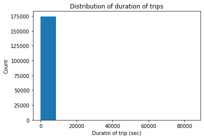

```python
#use visualization as support tool to detect if really is there outlier in Duration_sec
plt.hist(data = trips, x = 'duration_sec');
plt.xlabel('Duratin of trip (sec)');
plt.ylabel('Count')
plt.title("Distribution of duration of trips");
```

**From above graph is appear that is abig outliers in trips data and we must handle these outlier.We will do that by using z-score value**

```python
trips = trips[(np.abs(stats.zscore(trips['duration_sec'])) < 3)]
trips.shape
```

```
(174199, 16)
```

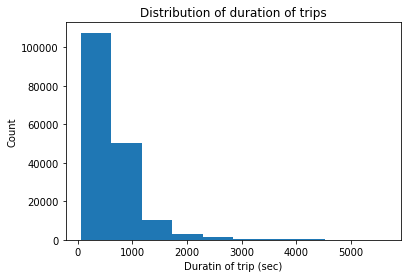

```python
#make sure that deleting outlier affecting on visualization
plt.hist(data = trips, x = 'duration_sec');
plt.xlabel('Duratin of trip (sec)');
plt.ylabel('Count')
plt.title("Distribution of duration of trips");
```

### 3- Get the distance maked in every trip

**Getting trip distance from late and long is not accurate because it get the shortest line distance between the two station and it's not true because there are curves , uterns and traffic conditions between the two station but it still indication we can use in our analysis and we also getting another information from it like the speed of every trip**

```python
trips.info()
```

```
<class 'pandas.core.frame.DataFrame'>
Int64Index: 174199 entries, 4 to 183411
Data columns (total 16 columns):
 #   Column                   Non-Null Count   Dtype
---  ------                   --------------   -----
 0   duration_sec             174199 non-null  int64
 1   start_time               174199 non-null  object
 2   end_time                 174199 non-null  object
 3   start_station_id         174199 non-null  float64
 4   start_station_name       174199 non-null  object
 5   start_station_latitude   174199 non-null  float64
 6   start_station_longitude  174199 non-null  float64
 7   end_station_id           174199 non-null  float64
 8   end_station_name         174199 non-null  object
 9   end_station_latitude     174199 non-null  float64
 10  end_station_longitude    174199 non-null  float64
 11  bike_id                  174199 non-null  int64
 12  user_type                174199 non-null  object
 13  member_birth_year        174199 non-null  float64
 14  member_gender            174199 non-null  object
 15  bike_share_for_all_trip  174199 non-null  object
dtypes: float64(7), int64(2), object(7)
memory usage: 22.6+ MB
```

```python
#Get the distance of all trips accourding to latitude and langitude of start and end stations of trips
from math import sin, cos, sqrt, atan2,radians
R = 6373.0

#we need to convert latitude to radian before make calculations
lat1 = trips['start_station_latitude'].apply(lambda x: radians(x))
lon1 = trips['start_station_longitude'].apply(lambda x: radians(x))
lat2 = trips['end_station_latitude'].apply(lambda x: radians(x))
lon2 = trips['end_station_longitude'].apply(lambda x: radians(x))

#dlat is the difference between latitude of start station and end station
dlat = lat2 - lat1

#dlon is the difference between longitude of start station and end station
dlon = lon2 - lon1

#finally get the distance through following equations
a = dlat.apply(lambda x: sin(x / 2)**2) + lat1.apply(lambda x: cos(x)) * lat2.apply(lambda x: cos(x)) * dlon.apply(lambda x: sin(x / 2)**2)
c = 2 * a.apply(lambda x: atan2(sqrt(x), sqrt(1 - x)))

trips['distance'] = R * c
```

```python
#Distace of trips in km
trips['distance'].head()
```

```
4    2.410058
5    3.333249
6    2.029188
7    4.533991
8    4.533991
Name: distance, dtype: float64
```

**ِAlso now we can get the speed of every trip**

```python
#Get duration in hr
trips['duration_sec']/3600
```

```
4         0.440278
5         0.498056
6         0.318611
7         0.448611
8         0.436111
            ...
183407    0.133333
183408    0.086944
183409    0.039167
183410    0.038611
183411    0.075278
Name: duration_sec, Length: 174199, dtype: float64
```

```python
#Get speed in km/hr
trips['speed'] = trips['distance']/(trips['duration_sec']/3600)
trips['speed']
```

```
4          5.473948
5          6.692524
6          6.368855
7         10.106730
8         10.396413
            ...
183407    10.989196
183408    16.138539
183409     9.681315
183410    19.360154
183411     9.439939
Name: speed, Length: 174199, dtype: float64
```

### 4-Get age of all users in 2019 from member_birth_year to be more clear in visualization

```python
#get the age of all user's from their date of birth to 2019
trips['age'] = 2019 - trips['member_birth_year']
trips['age']
```

```
4         45.0
5         60.0
6         36.0
7         30.0
8         31.0
          ...
183407    23.0
183408    35.0
183409    29.0
183410    31.0
183411    30.0
Name: age, Length: 174199, dtype: float64
```

### The New table after adjustment

```python
#Get the shape new table after adjustments
trips.head()
```

|  | duration_sec | start_time | end_time | start_station_id | start_station_name | start_station_latitude | start_station_longitude | end_station_id | end_station_name | end_station_latitude | end_station_longitude | bike_id | user_type | member_birth_year | member_gender | bike_share_for_all_trip | distance | speed | age |
| --- | --- | --- | --- | --- | --- | --- | --- | --- | --- | --- | --- | --- | --- | --- | --- | --- | --- | --- | --- |
| 4 | 1585 | 2019-02-28 23:54:18.5490 | 2019-03-01 00:20:44.0740 | 7.0 | Frank H Ogawa Plaza | 37.804562 | -122.271738 | 222.0 | 10th Ave at E 15th St | 37.792714 | -122.248780 | 4898 | Subscriber | 1974.0 | Male | Yes | 2.410058 | 5.473948 | 45.0 |
| 5 | 1793 | 2019-02-28 23:49:58.6320 | 2019-03-01 00:19:51.7600 | 93.0 | 4th St at Mission Bay Blvd S | 37.770407 | -122.391198 | 323.0 | Broadway at Kearny | 37.798014 | -122.405950 | 5200 | Subscriber | 1959.0 | Male | No | 3.333249 | 6.692524 | 60.0 |
| 6 | 1147 | 2019-02-28 23:55:35.1040 | 2019-03-01 00:14:42.5880 | 300.0 | Palm St at Willow St | 37.317298 | -121.884995 | 312.0 | San Jose Diridon Station | 37.329732 | -121.901782 | 3803 | Subscriber | 1983.0 | Female | No | 2.029188 | 6.368855 | 36.0 |
| 7 | 1615 | 2019-02-28 23:41:06.7660 | 2019-03-01 00:08:02.7560 | 10.0 | Washington St at Kearny St | 37.795393 | -122.404770 | 127.0 | Valencia St at 21st St | 37.756708 | -122.421025 | 6329 | Subscriber | 1989.0 | Male | No | 4.533991 | 10.106730 | 30.0 |
| 8 | 1570 | 2019-02-28 23:41:48.7900 | 2019-03-01 00:07:59.7150 | 10.0 | Washington St at Kearny St | 37.795393 | -122.404770 | 127.0 | Valencia St at 21st St | 37.756708 | -122.421025 | 6548 | Subscriber | 1988.0 | Other | No | 4.533991 | 10.396413 | 31.0 |

**Let's go in Epletory Visualization**  
**First univariant visualization discovering of different numirc and categorial data**

#### 1 -We can use log scale in previous histogram and reduce bin size to appear more details in data**

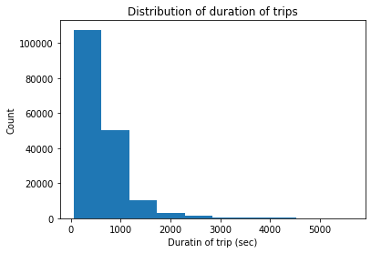

```python
#Let's start with univaiant visualization of duration_sec
plt.hist(data = trips, x = 'duration_sec');
plt.xlabel('Duratin of trip (sec)');
plt.ylabel('Count')
plt.title("Distribution of duration of trips");
```

```python
#there is alot of data focusing between 0 and 1000 secound so we need to scale these visualization to make it more clear
np.log10(trips['duration_sec'].describe())
```

```
count    5.241046
mean     2.800966
std      2.699111
min      1.785330
25%      2.507856
50%      2.705864
75%      2.894316
max      3.750508
Name: duration_sec, dtype: float64
```

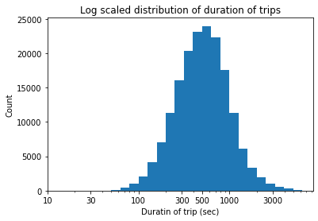

```python
#to make the log scaled visualization clear for ordinry users we need to adjust view things
#reduce bin size
bins = 10 ** np.arange(1.5, 3.8+.1, 0.1)

#change the ticks to true values
ticks = [10, 30, 100, 300,500, 1000,3000]
labels = ['{}'.format(v) for v in ticks]

#Finally excuate histogram and applied all changes
plt.hist(data=trips, x='duration_sec', bins=bins);
plt.xscale('log')
plt.xticks(ticks, labels);
plt.xlabel('Duratin of trip (sec)')
plt.ylabel('Count')
plt.title("Log scaled distribution of duration of trips");
```

**Now we can see that the data is normal distributed in log-scale and the most populer duration of trips is between 300 to 1000 secound**

#### 2-The most 15 stations as start stations

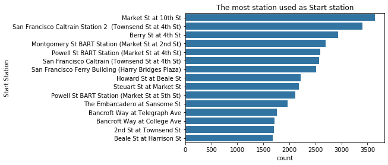

```python
base_color = sb.color_palette()[0]

# Get the indexes of beggist 15 statins in the Series
n = 15
staion_order = trips['start_station_name'].value_counts()[:n].index

# Plot the bar chart in the decreasing order of the frequency of the `start_station_name`
sb.countplot(data=trips, y='start_station_name', color=base_color, order=staion_order);
plt.ylabel('Start Station')
plt.title("The most station used as Start station");
```

#### 2-Get the most 15 stations as used distenation station

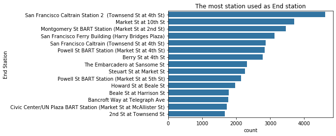

```python
base_color = sb.color_palette()[0]

# Get the indexes of beggist 15 statins in the Series
n = 15
staion_order = trips['end_station_name'].value_counts()[:n].index

# Plot the bar chart in the decreasing order of the frequency of the `end_station_name`
sb.countplot(data=trips, y='end_station_name', color=base_color, order=staion_order);
plt.ylabel('End Station')
plt.title("The most station used as End station");
```

**We can note that is alot of stations repeated in most station used as start station or distenation station.It's very good for availability of bikes for users but it make us asking what is the most station is have problem for availability of bike ? or what is the most station used as start but very low as distanation station? we may answer these question in Explantory part**

#### 3-Which are user_type have the biggest number of user's?

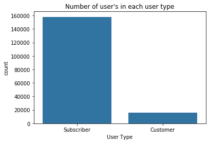

```python
#get the comparison in counts for user_types
sb.countplot(data=trips, x='user_type', color=base_color);
plt.xlabel('User Type')
plt.title("Number of user's in each user type");
```

**We can see here that the most of user's is subscriber's may we need to make more attaraction offers for ordaniry custumers**

#### 4-What are the most gender used the bikes?

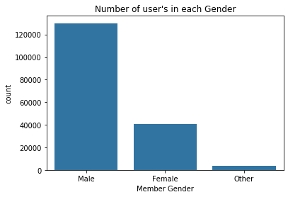

```python
#get the comparison in counts for member_gender
sb.countplot(data=trips, x='member_gender', color=base_color);
plt.xlabel('Member Gender')
plt.title("Number of user's in each Gender");
```

**from graph there is afew number's of female comparing to male so in explantory analysis We need to study why there is afew number of them. Is the distance of thier trips is too long to ride by bike or because there is no much bike available in start stations or most of them is not prefered to share bikes comparing to male user's or another reasons**

#### 5-last question in we can ask in univariant plots is what is the number of user's that prefered bike sharing?

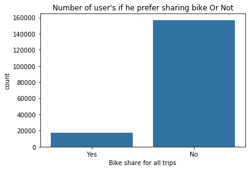

```python
#get the comparison in counts for bike_share_for_all_trip
sb.countplot(data=trips, x='bike_share_for_all_trip', color=base_color);
plt.xlabel('Bike share for all trips')
plt.title("Number of user's if he prefer sharing bike Or Not");
```

**We can see there is a very low of user's have no problem in bike sharing compared to others that not prefare sharing we can ask here why? is it because the long distance and the needed of speed to reduce the duration of trip or another reason**

## Bivariant Blots

#### 1-the relation between age and the duration of trips and also we can ask the relation between age and speed in trip in the same plot

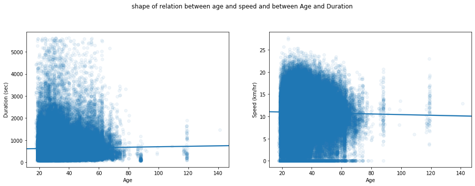

```python
plt.figure(figsize = [16, 5])
base_color = sb.color_palette()[0]

plt.subplot(1, 2, 1)

# reg plot to get relation between age and duration
sb.regplot(data = trips, x = 'age', y = 'duration_sec', truncate=False, x_jitter=0.3, scatter_kws={'alpha':1/15});
plt.xlabel('Age')
plt.ylabel('Duration (sec)')

plt.subplot(1, 2, 2)

# reg plot to get relation between age and speed
sb.regplot(data = trips, x = 'age', y = 'speed', truncate=False, x_jitter=0.3, scatter_kws={'alpha':1/15});
plt.xlabel('Age')
plt.ylabel('Speed (km/hr)')
plt.suptitle("shape of relation between age and speed and between Age and Duration", y = 1.04);
```

**We can see from above graph that the most of users prefer spend the least duration possible in trip and due of that the speed increase .I think we must make some advises in ride abike with high speed .We can see also there is a low inverse relation between speed and age it's good for old peaple but still there is another people ride in high speed and it not good for their sefty.The last thing we can note is there are very old people in 120 age is still ride abike is really amazing. Something like that may use as advertisement or insentive to attractive more users to use bikes**

#### 2-which gender prefere ride along distance and which are ride in more speed

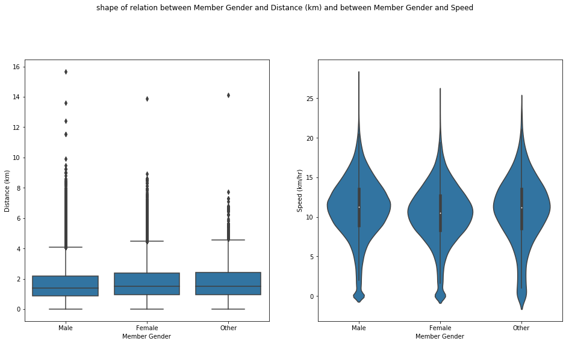

```python
plt.figure(figsize = [16, 8])
base_color = sb.color_palette()[0]

plt.subplot(1, 2, 1)

# box plot to get relation between member_gender and distance
sb.boxplot(data=trips, x='member_gender', y='distance', color=base_color)
plt.xlabel('Member Gender')
plt.ylabel('Distance (km)')

plt.subplot(1, 2, 2)

# vilon plot to get relation between member_gender and speed
sb.violinplot(data=trips, x='member_gender', y='speed', color=base_color, innner='quartile')
plt.xlabel('Member Gender')
plt.ylabel('Speed (km/hr)')
plt.suptitle("shape of relation between Member Gender and Distance (km) and between Member Gender and Speed", y = 1.04);
```

**We can there is almost no difference but we can see the female and other are ride along distance but there is afew man ride very long distance like 14 and 16 km .In speed the female is the lowest in speed it may one of reasons that make female take more time in riding so that she not prefare riding abike like mens and we can see that also in distance graph**

## Multivariant plots

#### 1-We can make matrix plot to relate all numric column with each others

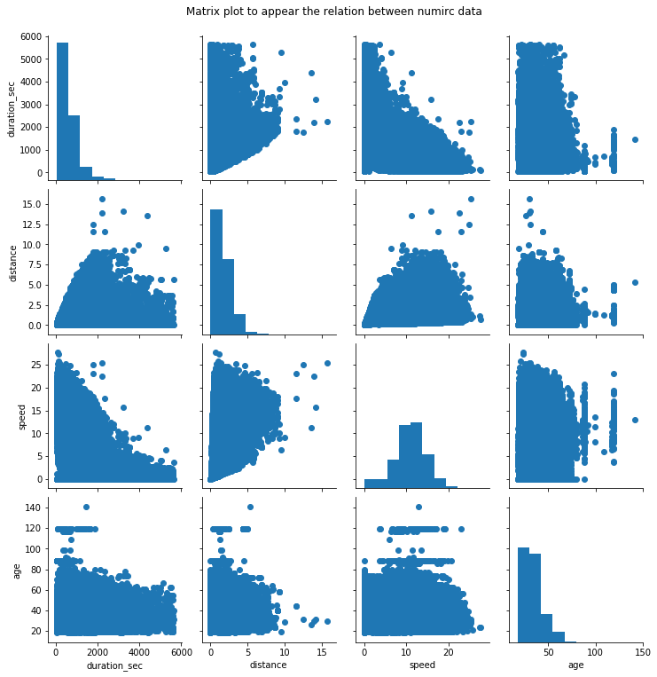

```python
# useing matrix plot to get all relations of numric values between each others
plt.figure(figsize = [40, 8]);
g = sb.PairGrid(data = trips, vars = ['duration_sec', 'distance', 'speed','age']);
g.map_diag(plt.hist);
g.map_offdiag(plt.scatter);
plt.suptitle('Matrix plot to appear the relation between numirc data', y = 1.04);
```

We can see afew notes  
1-speed is almost normal distributed  
2-relation between speed and distance is also almost normal distributed  
3-As expected the old age ride a shord distance and in a short duration but there is some of them not care about speed and some thing like that is dangerous in their life

#### 2-We can make the relation between previous numirc values more clear

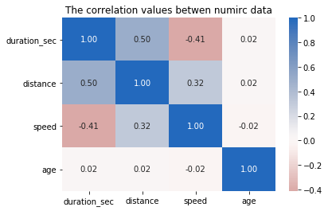

```python
#heatmap graph to know where is the strong and week relations in our data
corr = trips[['duration_sec', 'distance', 'speed','age']]
sb.heatmap(corr.corr(), annot = True, fmt = '.2f', cmap = 'vlag_r', center = 0);
plt.title("The correlation values betwen numirc data");
```

```python
#import data after adjustments to use it in explanatory part
trips.to_csv('new_trips.csv')
```